# FigureYa111markerGene_step1

### Violin Diagram

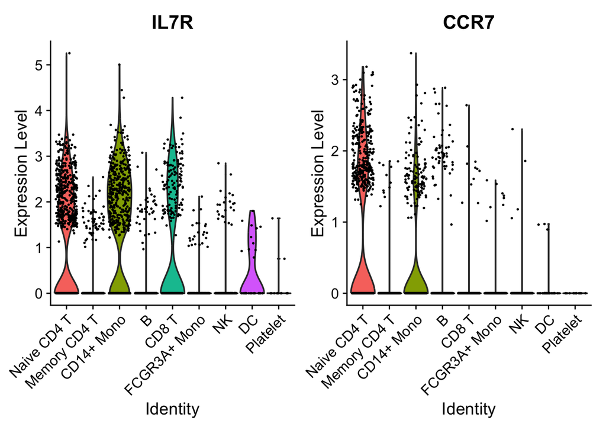

```r
# 绘制小提琴图展示IL7R和CCR7基因在各细胞聚类中的表达分布
# Generate violin plots to show the expression distribution of IL7R and CCR7 genes across cell clusters
VlnPlot(pbmc,
        features = marker_gene[1:2])  # 选取marker_gene向量中的前两个基因(IL7R和CCR7)
```

```r
                                  # Select the first two genes (IL7R and CCR7) from the marker_gene vector
```

> 除了这两种，还能不能有更加好看的展现方式？

Scanpy提供了许多种好看的展示方式，见https://scanpy-tutorials.readthedocs.io/en/latest/visualizing-marker-genes.html

那么如何将Seruat的结果和Scanpy进行结合呢？我们首先需要把结果输出到文件，然后用Scanpy画美图。

## 输出Seurat结果

Seurat的表达量数据存放在`@assays$RNA`下,

- counts: TPM或者UMI信息, 最初的输入信息
- data: 标准化结果
- scale.data: scale后的数据

Seurat的细胞的各种元信息在`@meta.data`下

Seurat定义后细胞类型的数据在`@active.ident`下,

我写了一个函数`seurat2scanpy`, 将上面信息保存在同一个文件夹下

> Can there be a more visually appealing way of presenting besides these two?

Scanpy provides many visually appealing display options, see< https://scanpy-tutorials.readthedocs.io/en/latest/visualizing-marker-genes.html >

So how to combine the results of Seruat with Scanpy? We first need to output the results to a file, and then use Scanpy to draw beautiful images.

## Output Seurat results

The expression level data of Seurat is stored under ‘@ assay $RNA’,

-Counts: TPM or UMI information, initial input information -Data: Standardized results -Scale.data: scaled data

The various meta information of Seurat’s cells can be found under ‘@ meta. data’

The data of cell types defined by Seurat can be found under ‘@ active. dent’,

I wrote a function called ‘seurat2scanpy’ and saved the above information in the same folder

```r
# 导入自定义函数脚本，该脚本包含将Seurat对象转换为Scanpy兼容格式的功能
# Source a custom function script that contains functions to convert Seurat objects to Scanpy-compatible formats
source("seurat2scanpy.R")

# 调用seurat2scanpy函数将处理好的pbmc Seurat对象转换为AnnData格式
# 以便后续使用Scanpy(Python)进行下游分析，如轨迹推断、RNA速度等
# Convert the processed Seurat object 'pbmc' into AnnData format
# for downstream analysis using Scanpy (Python), such as trajectory inference or RNA velocity analysis
seurat2scanpy(x = pbmc)  # x = 需要转换的Seurat对象
                         # x = Seurat object to be converted
```

后续的操作在Jupyter notebook进行。你需要：

- 下载并安装Anaconda发行版，https://www.anaconda.com/distribution/#download-section
- 用Jupyter notebook打开FigureYa111markerGene_step2_linuxMAC.ipynb或FigureYa111markerGene_step2_win10.ipynb文档继续画图。
- ipynb文档的用法参考这篇：https://mp.weixin.qq.com/s/G-CQhNEJBmMRuDe2kxND_w

## 参考资料

- https://scanpy.readthedocs.io/

The subsequent operations will be carried out in the Jupyter notebook. You need:

## Reference materials

- < https://scanpy.readthedocs.io/ >